# xwMOOC 데이터 과학

지역내총생산 (GRDP) - treemap

xwMOOC

2018-01-13

## 1. 지역내총생산(GRDP)

지역내총생산(GRDP: Gross Regional Domestic Product)은 어떤기간 동안 어떠한 지역에서 생산된 상품과 서비스의 가치를 시장가격으로 평가한 수치로 지역내총생산이 높다는 것은 그 지역 재정자립도가 높다는 것을 의미하고 반대로 지역내총생산이 낮다는 것은 재정자립도가 낮아 중앙정부의 지원이 필요하다는 것을 의미한다. 국내에선 통계청이 1985년부터 16개 광역 시·도의 GRDP를 산출해 발표하고 있으며 지역 경제 분석과 정책 수립에 필요한 기초자료로 활용한다. 국가로 치면 국내총생산(GDP)과 같은 개념이다.

[데이터 과학자와 함께 하는 제19대 대통령 선거 - 지역내총생산(GRDP) 변화](http://statkclee.github.io/politics/pe-grdp.html)를 참조하면 1985년부터 16개 광역시도 GRDP 연도별 변화를 살펴볼 수 있다.

## 2. 데이터 가져와서 정제

자료는 통계청 http://kosis.kr/ “국내통계 → 주제별통계 → 국민계정/지역계정 → 지역소득(2010년 기준)” 에서 시도 지역내총생산(GRDP) 데이터를 가져온다. 엑셀 파일을 `treemap` 팩키지가 받아들일 수 있는 적당한 형태로 가공한다.

```r
# 0. 환경설정 -----
library(rvest)
library(readxl)
library(stringr)
library(xts)
library(tidyverse)
library(gridExtra)
library(treemap)
library(d3treeR) # devtools::install_github("timelyportfolio/d3treeR")
library(extrafont)
loadfonts()

# 1. 데이터 가져오기 -----

sido_grdp_dat <- read_excel("data/행정구역_시도_별_경제활동별_지역내총생산_20180113231512.xlsx", sheet="데이터", skip=1)

# 2. 데이터 정제 -----

names(sido_grdp_dat) <- c("시도", "경제활동", "1985년", "1995년", "2005년", "2016년")

sido_grdp_df <- sido_grdp_dat %>%
  mutate(시도 = na.locf(시도)) %>%
  filter(시도 != "전국") %>%
  filter(!경제활동 %in% c("지역내총생산(시장가격)", "총부가가치(기초가격)")) %>%
  mutate(대분류 = ifelse(경제활동 == "순생산물세", "순생산물세", "총부가가치")) %>%
  rename(중분류 = 경제활동) %>%
  select(시도, 대분류, 중분류, everything()) %>%
  mutate_if(is.character, as.factor)

DT::datatable(sido_grdp_df) %>%
  DT::formatCurrency(c("1985년", "1995년", "2005년", "2016년"), currency="", digits=0)
```

|  | 시도 | 대분류 | 중분류 | 1985년 | 1995년 | 2005년 | 2016년 |
| --- | --- | --- | --- | --- | --- | --- | --- |
| 1 | 서울특별시 | 순생산물세 | 순생산물세 | 2391443 | 8360205 | 20809638 | 31750605 |
| 2 | 서울특별시 | 총부가가치 | 농림어업 | 161874 | 427070 | 376696 | 471606 |
| 3 | 서울특별시 | 총부가가치 | 광업 | 22792 | 15682 | 91121 | 23609 |
| 4 | 서울특별시 | 총부가가치 | 제조업 | 2284262 | 8482208 | 11803893 | 20157884 |
| 5 | 서울특별시 | 총부가가치 | 전기,가스,증기및수도사업 | 181738 | 616803 | 1711061 | 2281713 |
| 6 | 서울특별시 | 총부가가치 | 건설업 | 1616527 | 7208420 | 9342840 | 10510434 |
| 7 | 서울특별시 | 총부가가치 | 도매및소매업 | 5065512 | 17465875 | 30691985 | 55598161 |
| 8 | 서울특별시 | 총부가가치 | 운수업 | 1239075 | 6346421 | 7748262 | 10856419 |
| 9 | 서울특별시 | 총부가가치 | 숙박및음식점업 | 363991 | 4111341 | 6548752 | 11142019 |
| 10 | 서울특별시 | 총부가가치 | 출판,영상, 방송통신 및 정보서비스업 | 1006771 | 6900163 | 21626462 | 32338262 |

[output cut: 262 more lines]

## 3. 2016년 광역시도 지역내총생산(GRDP)

먼저 2016년 광역시도 지역내 총생산을 살펴보자.

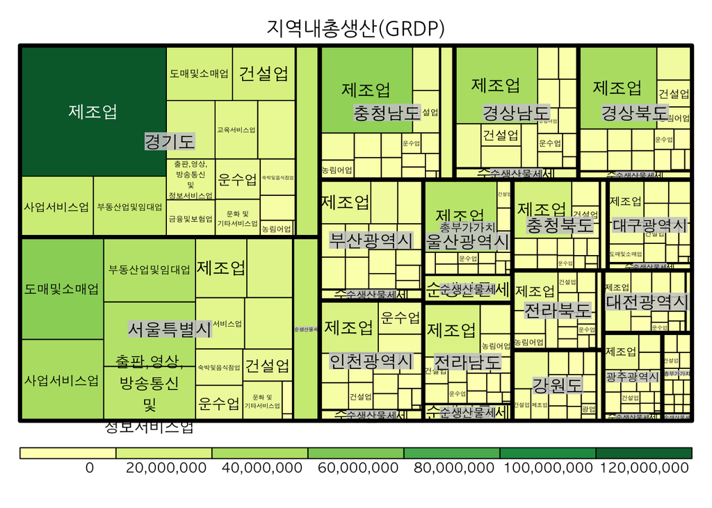

```r
# 3. 시도별 GRDP 시각화 -----
## 3.1. 2016년: treemap 정적 그래프
grdp_2016_treemap <- treemap(sido_grdp_df,
                            index = c("시도", "대분류", "중분류"),
                            vSize = "2016년",
                            vColor = "2016년",
                            title = "지역내총생산(GRDP)",
                            fontsize.labels=c(12, 8),
                            draw = TRUE,
                            type = "value",
                            fontfamily.title = "NanumGothic",
                            format.legend = list(scientific = FALSE, big.mark = ","),
                            title.legend="")
```

`treemap` 인터랙티브 방식으로 파고들어(drilldown)하여 2016년 각 시도별 지역내 총생산을 살펴보자.

```r
## 3.2. 2016년: treemap 동적 그래프
d3tree3(grdp_2016_treemap, rootname = "대한민국")
```

[interactive chart not shown]

## 4. 1985년 광역시도 지역내총생산(GRDP)

먼저 1985년 광역시도 지역내총생산을 살펴보자. 30년 사이 지역내총생산(GRDP) 변화를 체감할 수 있다.

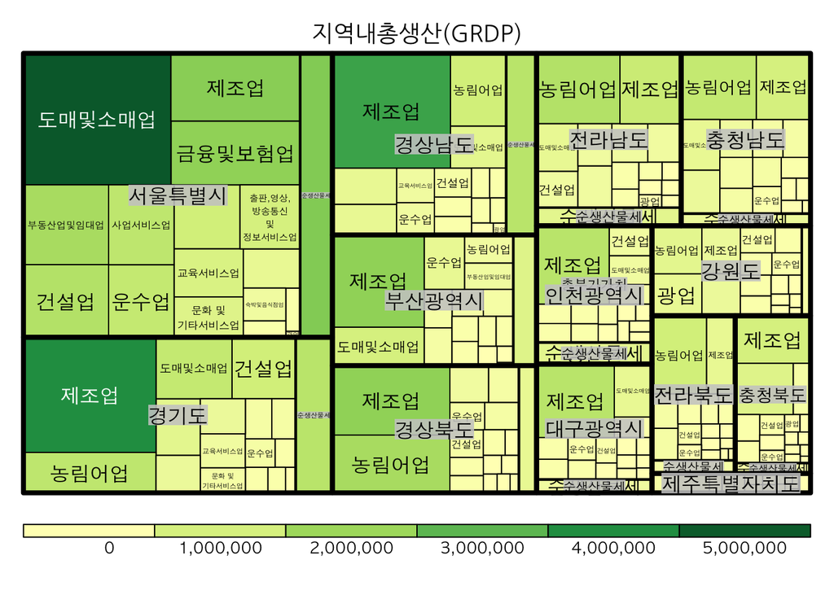

```r
## 3.3. 1985년: treemap 정적 그래프
grdp_1985_treemap <- treemap(sido_grdp_df,
                             index = c("시도", "대분류", "중분류"),
                             vSize = "1985년",
                             vColor = "1985년",
                             title = "지역내총생산(GRDP)",
                             fontsize.labels=c(12, 8),
                             draw = TRUE,
                             type = "value",
                             fontfamily.title = "NanumGothic",
                             format.legend = list(scientific = FALSE, big.mark = ","),
                             title.legend="")
```

`treemap` 인터랙티브 방식으로 파고들어(drilldown)하여 1985년 각 시도별 지역내 총생산을 살펴보자.

```r
## 3.4. 1985년: treemap 동적 그래프
d3tree2(grdp_1985_treemap, rootname = "대한민국")
```

[interactive chart not shown]